# Laboratorio di Programmazione Gr. 3 (N-Z)

# Corso di Laurea in Informatica

## Università degli Studi di Napoli Federico II

## A.A. 2021/22

# **Input e Output su file**

2 tipologie di file:

- file *ASCII* (o di testo)
- file *binari*

  Esempio di creazione di un file **binario**:

```python
#include <stdio.h>
int main()
{
    int v[] = {64, 77, 48, 92};
    FILE* fp;
    fp = fopen("vettore.bin","wb");

    fwrite(v, sizeof(int), 4, fp);

    fclose(fp);

    return 0;
}
```

`cat vettore.bin`

```
@M0
```

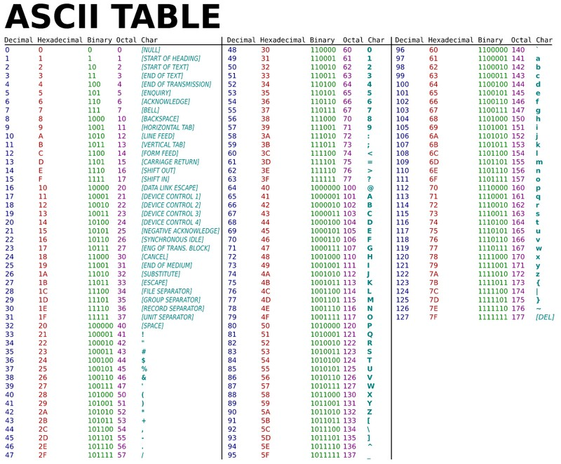

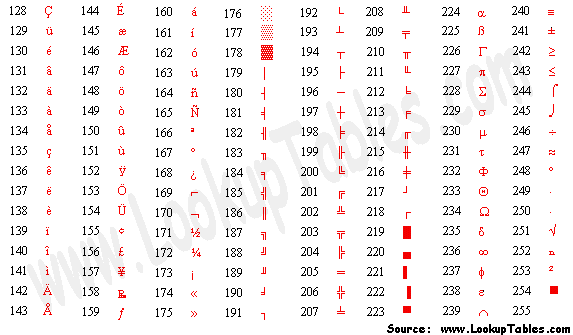

Da terminale:

`xxd -b vettore.bin`

```
00000000: 01000000 00000000 00000000 00000000 01001101 00000000  | @...M.
00000006: 00000000 00000000 00110000 00000000 00000000 00000000  | ..0...
0000000c: 01011100 00000000 00000000 00000000                    | \...
```

- 00000000 00000000 00000000 01000000 è la codifica binaria di 64 su 4 byte
- 00000000 00000000 00000000 01001101 è la codifica binaria di 77 su 4 byte
- 00000000 00000000 00000000 00110000 è la codifica binaria di 48 su 4 byte
- 00000000 00000000 00000000 01011100 è la codifica binaria di 92 su 4 byte

Esempio di creazione di un file di **testo**:

```python
#include <stdio.h>
int main()
{
    int v[] = {64, 77, 48, 92};
    FILE* fp;
    fp = fopen("vettore.txt","w");

    for(int i=0; i<4; i++)
        fprintf(fp,"%d, ", v[i]);

    fclose(fp);

    return 0;
}
```

Da terminale:

`cat vettore.txt`

[output not shown]

`xxd -b vettore.txt`

[output not shown]

- 00110110 è la codifica ASCII del 6
- 00110100 è la codifica ASCII del 4
- 00100000 è la codifica ASCII dello spazio ....
- In un file di testo, le cifre di ogni numero vengono convertite nei *caratteri* ASCII corrispondenti prima di essere scritte, così da poter essere facilmente lette da un essere umano attraverso un editor di testo
- In un file binario, ogni valore è scritto nella sua codifica originaria, senza senza che sia effettuata alcuna trasformazione

# **Apertura e chiusura di un file**

Le funzioni per la gestione dei file sono generalmente dichiarate (o comunque incluse) in `stdio.h`.

In generale, per aprire e chiudere un file si usano rispettivamente le funzioni `fopen(...)` ed `fclose(...)`.

### **`fopen(...)`**

La funzione `fopen(...)` ha il seguente prototipo:

`FILE* fopen ( const char * filename, const char * mode );`

Tale funzione accetta due parametri: il nome del file (stringa), e la *modalità di accesso* (stringa).

La modalità di accesso permette di stabilire due cose:

1. se vogliamo leggere/scrivere sul file
2. se vogliamo leggere o scrivere un file in modalità binaria o testuale

[output not shown]

Tale funzione restituisce un puntatore di tipo `FILE`.

> `FILE`: [struct] that identifies a stream and contains the information needed to control it, including a pointer to its buffer, its position indicator and all its state indicators.

Tale struttura è definita (o comunque inclusa) in `stdio.h`.

Generalmente la struttura FILE di un dato file è chiamata anche *file handler*.

```
struct _IO_FILE
{
  int _flags;           /* High-order word is _IO_MAGIC; rest is flags. */

  /* The following pointers correspond to the C++ streambuf protocol. */
  char *_IO_read_ptr;   /* Current read pointer */
  char *_IO_read_end;   /* End of get area. */
  char *_IO_read_base;  /* Start of putback+get area. */
  char *_IO_write_base; /* Start of put area. */
  char *_IO_write_ptr;  /* Current put pointer. */
  char *_IO_write_end;  /* End of put area. */
  char *_IO_buf_base;   /* Start of reserve area. */
  char *_IO_buf_end;    /* End of reserve area. */

  /* The following fields are used to support backing up and undo. */
  char *_IO_save_base; /* Pointer to start of non-current get area. */
  char *_IO_backup_base;  /* Pointer to first valid character of backup area */
  char *_IO_save_end; /* Pointer to end of non-current get area. */

  struct _IO_marker *_markers;

  struct _IO_FILE *_chain;

  int _fileno;
  int _flags2;
  __off_t _old_offset; /* This used to be _offset but it's too small.  */

  /* 1+column number of pbase(); 0 is unknown. */
  unsigned short _cur_column;
  signed char _vtable_offset;
  char _shortbuf[1];

  _IO_lock_t *_lock;
#ifdef _IO_USE_OLD_IO_FILE
};

typedef struct _IO_FILE FILE;
```

I campi di questa struttura saranno utilizzati dalle funzioni di scrittura/lettura per accedere materialmente al file.

## **fclose(...)**

Una volta che il file non deve più essere utilizzato, è buona norma chiuderlo.

La chiusura di un file può essere effettuata attraverso la funzione `fclose(...)`

- int fclose(FILE *stream)

esempio:

```
// apro il file
FILE* file_handler = fopen(...);
// effettuo operazione sul file...

// terminate le operazioni sul file, chiudo il file
fclose(file_handler);
```

é buona norma chiudere **sempre** un file una volta finito di utilizzarlo. Sia per liberare risorse (e.g., la struct `FILE` occupa spazio in memoria) sia per permettere di finalizzare eventuali operazioni sospese (e.g., le operazioni di scrittura sul file non è detto che avvengano all'atto dell'invocazione della funzione di scrittura).

Se l'operazione va a buon fine, `fclose(...)` restituisce $0$.

## **File Binari**

### **Scrittura e lettura in un file binario**

- `fwrite ( const void* ptr, size_t size, size_t nitems, FILE * stream );`

La funzione `fwrite(...)` scrive, sul file puntato da `stream`, (fino a) `nitems` elementi di dimensione `size` (in Byte), a partire dall'indirizzo specificato in `ptr`. tale funzione restituisce il numero di elementi correttamente scritti. Se tutto è andato bene, tale valore sarà pari a `nitems`.

Otherwise, if a write error occurs, the error indicator for the stream is set and errno is set to indicate the error.

- `fread(void *ptr, size_t size, size_t nitems, FILE *stream);`

La funzione `fread(...)` legge, dal file puntato da `stream`, (fino a) `nitems` di dimensione `size` (in Byte). La funzione restituisce il numero di elementi correttamente letti. Tale valore sarà `< nitems` solo se c'è un errore oppure il file è finito prima di riuscire a leggere `nitems` elementi.

```python
#include <stdio.h>
#define MAX_LEN 100

void stampa_vett(int v[], int n)
{
    printf("( ");
    for(int i=0; i<4; i++)
        printf("%d, ", v[i]);
    printf("\b\b)\n");

}

int main()
{
    int v[] = {64, 77, 48, 92};
    FILE* fp;
    fp = fopen("vettore.bin","wb");

    int n_scritti = fwrite(v, sizeof(int), 4, fp);

    fclose(fp);

    printf("scritto: ");
    stampa_vett(v, n_scritti);

    // lettura
    fp = fopen("vettore.bin","rb");
    int v2[MAX_LEN];
    int n2 = 0;

    int readed = 1;
    while(readed >=1)
    {
        readed = fread(&v2[n2], sizeof(int),1, fp);
        n2++;

    }
    fclose(fp);

    printf("letto: ");
    stampa_vett(v2, n2);



    return 0;
}
```

```
scritto: ( 64, 77, 48, 92)
letto: ( 64, 77, 48, 92)
```

L'esempio precedente non sfrutta appieno la funzione `fread(...)` in quanto:

- necessita di più invocazioni, una per ogni elemento da leggere dal file
- basandosi unicamente sull numero di valori letti dalla funzione `fread(...)` per terminare, non permette di avere nello stesso file più strutture diverse (e.g., più array) memorizzati nello stesso file

Possibile soluzione: Salvare all'interno del file *informazioni addizionali* in testa, ad esempio la lunghezza dell'array

```python
#include <stdio.h>
#define MAX_LEN 100

void stampa_vett(int v[], int n)
{
    printf("( ");
    for(int i=0; i<4; i++)
        printf("%d, ", v[i]);
    printf("\b\b)\n");

}

int main()
{
    int v[] = {64, 77, 48, 92};
    int n   = 4;
    FILE* fp;
    fp = fopen("vettore.bin","wb");

    // scrivo il numero di elementi dell'array in testa al file
    fwrite(&n, sizeof(int), 1, fp);

    // provo a scrivere n*sizeof(int) Bytes nel file
    int n_scritti = fwrite(v, sizeof(int), n, fp);

    fclose(fp);

    printf("scritto: ");
    stampa_vett(v, n_scritti);

    // lettura
    fp = fopen("vettore.bin","rb");
    int v2[MAX_LEN];
    int n2 = 0;
    // leggo numero di elementi dell'array in testa al file
    fread(&n2, sizeof(int), 1, fp);

    // leggo n2 elementi (ossia n2*sizeof(int) Bytes)
    fread(v2, sizeof(int), n2, fp);

    fclose(fp);

    printf("letto:   ");
    stampa_vett(v2, n2);



    return 0;
}
```

```
scritto: ( 64, 77, 48, 92)
letto:   ( 64, 77, 48, 92)
```

## **File di testo**

### **Scrittura e lettura in un file di testo**

Diverse funzioni possibili:

- `int fputc( int c, FILE *fp );` Scrive il carattere con codifica ASCII `c` sul file gestito da `fp`. In caso di successo, restituisce il carattere scritto.
- `int fputs( const char *s, FILE *fp );` The function fputs() writes the string s to the output stream referenced by fp. It returns a non-negative value on success.
- `int fprintf(FILE *restrict stream, const char *restrict format, ...);` come `printf(...)`, ma su file di testo.
- `int fgetc( FILE * fp );` legge un caratter dal file gestito da `fp` e ne restituisce la codifica ASCII.
- `char *fgets( char *buf, int n, FILE *fp );` legge al più $n-1$ caratteri dal file gestito da `fp`. Copia la stringa letta nell'area di memoria puntata da `buf`, aggiungendo un terminatore di stringa (ossia, dopo l'ultimo carattere letto, viene inserito nel buffer il carattere '\0'). Se nella stringa letta c'è un `\n` oppure il file termina prima di leggere $n-1$ caratteri, allora `buf` conterrà solo i caratteri letti fino a quel puno, incluso il `\n`. Se funzione viene completata con successo, allora il valore di ritorno sarà lo stesso di `buf`.
- `int fscanf(FILE *restrict stream, const char *restrict format, ...);` Come `scanf(...)`, ma legge dal file di testo gestito da `stream`. NB: ricordate però come la `scanf(...)` si comporta in presenza di spazi...

```python
// esempio di utilizzo di fputs(...)

#include <stdio.h>
int main()
{
    // apertura in scrittura
    FILE* fp = fopen("stringa.txt","w");
    if (fp == NULL)
    {
        printf("qualcosa è andato storto!\n");
        return 1;
    }

    // scrittura
    int rit = fputs("ciao pluto", fp);
    printf("fputs: valore di ritorno: %d\n", rit);

    fclose(fp);

    // apertura in lettura
    char str[30];
    fp = fopen("stringa.txt","r");
    char* str_rit  = fgets(str,30, fp);
    // lettura
    printf("fgets:  *str_rit:%s, *str:%s\n", str_rit, str);
    printf("fgets:  str_rit: %p,  str:%p\n", str_rit, str);
    printf("fgets:  valore di ritorno: %d\n", rit);

    fclose(fp);


    return 0;
}
```

```
fputs: valore di ritorno: 1
fgets:  *str_rit:ciao pluto, *str:ciao pluto
fgets:  str_rit: 0x7ffec8771370,  str:0x7ffec8771370
fgets:  valore di ritorno: 1
```

Cosa succede nel caso di lettura di un file terminato (ossia in cui già è stato letto tutto e non c'è più nulla da leggere)?

Iniziamo con la funzione `fgets(...)`. Tale funzione, in caso tentativo di lettura da file terminato, restituisce `NULL`. Ma attenzione...

```python
// attenzione...

#include <stdio.h>
int main()
{
    // apertura in scrittura
    FILE* fp = fopen("stringa.txt","w");
    if (fp == NULL)
    {
        printf("qualcosa è andato storto!\n");
        return 1;
    }

    // scrittura
    int rit = fprintf(fp, "ciao Pluto come stai?\nBene grazie");
    printf("fprintf: valore di ritorno: %d\n", rit);

    fclose(fp);

    // apertura in lettura

    fp = fopen("stringa.txt","r");

    // lettura
    char str[30];
    rit  = fscanf(fp, "%s", str);

    printf("fscanf:  *str:%s\n", str);
    printf("fscanf:  valore di ritorno: %d\n", rit);

    // prima invocazione di fgets
    char* rit_str = fgets(str,30, fp);
    printf("(1) fgets:  *str:%s\n", str);
    printf("(1) fgets:  valore di ritorno: %p\n", rit_str);
    // seconda invocazione di fgets
    rit_str = fgets(str,30, fp);
    printf("(2) fgets:  *str:%s\n", str);
    printf("(2) fgets:  valore di ritorno: %p\n", rit_str);
    // terza invocazione di fgets
    rit_str = fgets(str,30, fp);
    printf("(3) fgets:  *str:%s\n", str);
    printf("(3) fgets:  valore di ritorno: %p\n", rit_str);
    fclose(fp);


    return 0;
}
```

```
fprintf: valore di ritorno: 33
fscanf:  *str:ciao
fscanf:  valore di ritorno: 1
(1) fgets:  *str: Pluto come stai?

(1) fgets:  valore di ritorno: 0x7ffe275df630
(2) fgets:  *str:Bene grazie
(2) fgets:  valore di ritorno: 0x7ffe275df630
(3) fgets:  *str:Bene grazie
(3) fgets:  valore di ritorno: (nil)
```

Non tenere conto di ciò potrebbe portare ad una implementazione ingenua come la seguente:

```python
// Leggere un file di testo e stampare a video tutte le righe presenti (implementazione errata)

#include <stdio.h>
int main()
{
    // apertura in scrittura
    FILE* fp = fopen("stringa.txt","w");
    if (fp == NULL)
    {
        printf("qualcosa è andato storto!\n");
        return 1;
    }

    // scrittura
    fprintf(fp, "ciao Pluto come stai?\nBene grazie");

    fclose(fp);

    // apertura in lettura

    fp = fopen("stringa.txt","r");
    char str[30];
    char* rit_str = str;
    while(rit_str != NULL)
    {

        rit_str = fgets(str,30, fp);
        printf("fgets: %s\n", str);
    }
    fclose(fp);


    return 0;
}
```

```
fgets: ciao Pluto come stai?

fgets: Bene grazie
fgets: Bene grazie
```

Il codice di sopra stampa due volte l'ultima riga. Questo perchè `rit_str` diventerà `NULL` solo quando `fgets(...)` non riuscirà a leggere materialmente nulla dal file in quanto terminato (lasciando quindi `str` inalterata), e ciò avverrà solo alla terza iterazione (e non alla seconda).

Possibile soluzione:

```python
// Leggere un file di testo e stampare a video tutte le righe presenti (soluzione 1)
#include <stdio.h>
int main()
{
    // apertura in scrittura
    FILE* fp = fopen("stringa.txt","w");
    if (fp == NULL)
    {
        printf("qualcosa è andato storto!\n");
        return 1;
    }

    // scrittura
    fprintf(fp, "ciao Pluto come stai?\nBene grazie");

    fclose(fp);

    // apertura in lettura

    fp = fopen("stringa.txt","r");
    char str[30];
    char* rit_str = str;
    while(rit_str != NULL)
    {

        rit_str    = fgets(str,30, fp);
        if(rit_str != NULL)
            printf("fgets: %s\n", str);
    }
    fclose(fp);


    return 0;
}
```

```
fgets: ciao Pluto come stai?

fgets: Bene grazie
```

Oppure...

```python
// Leggere un file di testo e stampare a video tutte le righe presenti (soluzione 2)
#include <stdio.h>
int main()
{
    // apertura in scrittura
    FILE* fp = fopen("stringa.txt","w");
    if (fp == NULL)
    {
        printf("qualcosa è andato storto!\n");
        return 1;
    }

    // scrittura
    fprintf(fp, "ciao Pluto come stai?\nBene grazie");

    fclose(fp);

    // apertura in lettura

    fp = fopen("stringa.txt","r");
    char str[30];

    while(fgets(str,30, fp) != NULL) // controllo il valore di ritorno stesso all'interno del ciclo
    {
        printf("fgets: %s\n", str);
    }
    fclose(fp);


    return 0;
}
```

```
fgets: ciao Pluto come stai?

fgets: Bene grazie
```

# **The curse of *End Of File***

Quando una funzione prova a leggere un file *terminato*, viene segnalata **internamente** (ad esempio attraverso un flag nel file handler) una condizione di *end-of-file*. *A prescindere da questo*, ogni funzione adotta una politica differente nel caso in cui si provi ad accedere ad un file terminato. Le principali sono:

| **function** | **In caso di end-of-file (o errore) restituisce** |
| --- | --- |
| fgets(...) | NULL |
| fgetc(...) | EOF |
| fread(...) | numero di elementi letti minore di quanto atteso |

`EOF` è una macro definita in `stdio.h` (o in qualche file `.h` da questultimo a sua volta incluso).

**NB:**`EOF` $\not\equiv$ `end-of-file`;

- `EOF` è una macro definita da qualche parte (e.g., `#define EOF -1` in `stdio.h` o in file da questo inclusi). E' un valore che è restituito da *alcune* (e non tutte!) le funzioni della liberia standard quando si prova a leggere da un file terminato. Generalmente il suo valore è `-1`, o comunque un valore $< 0$.
- *end-of-file* è un possibile *stato* del file, generalmente identificato da un apposito flag nel file handler. Tale flag nasce per dire se il file è terminato oppure no. Il valore di tale flag viene generalmente impostato quando le funzioni di accesso al file (e.g., `fread(...)`, `fgets(...)`, ecc.) provano a leggere da un file *già terminato* in precedenza L'accesso in lettura a tale flag (ossia sapere quale valore contiene in un dato istante) è possibile tramite la funzione `feof(...)`.

`int feof(FILE *stream)`:

controlla se, *a seguito dell'ultima lettura effettuata*, il file è terminato, ossia è stato impostato lo *stato* *end-of-file*.

In altri termini, `feof(fp)` restituisce un valore $\neq 0 $ se l'indicatore *end-of-file* associato al file-handler `*fp` è impostato, altrimenti restituisce $0$.

**SCONSIGLIATA!**

Esempio:

contenuto file `testo.txt`:

```
topolino
paperino
```

```python
// lettura di un file di testo e stampa a video di ogni riga (versione errata!)

#include <stdio.h>
int main()
{
    // apertura in lettura

    FILE* fp = fopen("testo.txt","r");
    char str[30];
    while(feof(fp) == 0)
    {

        fgets(str,sizeof(str), fp);
        printf("fgets: %s\n", str);
    }
    fclose(fp);


    return 0;
}
```

```
fgets: topolino

fgets: paperino

fgets: paperino
```

- 1° invocazione di `fgets(...)`: legge `topolino` (ma non imposta lo stato *end-of-file*)
- 2° invocazione di `fgets(...)`: legge `paperino` (ma non imposta lo stato *end-of-file*)
- 3° invocazione di `fgets(...)`: il file è terminato quindi non legge nulla, lascia `str` inalterato ed imposta lo stato di *end-of-file*

```python
// lettura di un file di testo e stampa a video di ogni riga (versione corretta)

#include <stdio.h>
int main()
{
    // apertura in lettura

    FILE* fp = fopen("testo.txt","r");
    char str[30];
    while(fgets(str,sizeof(str), fp)!= NULL)
    {

        printf("fgets: %s\n", str);
    }
    fclose(fp);


    return 0;
}
```

```
fgets: topolino

fgets: paperino
```

```python
// lettura di un file di testo e stampa a video di ogni parola attraverso funzione fscanf
// (versione corretta)

#include <stdio.h>
int main()
{
    // apertura in lettura

    FILE* fp = fopen("testo.txt","r");
    char str[30];
    while(fscanf(fp, "%s", str) > 0)
    {

        printf("fscanf: %s\n", str);
    }
    fclose(fp);

    return 0;
}
```

```
fscanf: topolino
fscanf: paperino
```

**Consiglio:** non utilizzare la funzione `feof(...)`, utilizzare invece in maniera corretta i valori di ritorno delle diverse funzioni di accesso ai file.

## **STDIN/STDOUT/STDERR**

definite in `<stdio.h>`

- `FILE* stdin;` ogni lettura da tastiera viene vista come una lettura dal file definito dalla struct (puntata da) stdin
- `FILE* stdout;` ogni scrittura sul file definito dalla struct (puntata da) stdout viene vista come una scrittura sul monitor
- `FILE *stderr;` associato tipicamente con il monitor ed è utilizzato per visualizzare messaggi di errore.

Alcune funzioni, ad esempio `getchar(...)` e `putchar(...)`, usano automaticamente `stdin` e `stdout`

`getchar(...)` $\equiv$ `getc(stdin,...)`

`printf(...)` $\equiv$ `fprintf(stdout,...)`

`scanf(...)` $\equiv$ `fscanf(stdin,...)`

per stampare un messaggio su `stderr`, si può usare la funzione

`void perror(const char *s);`

```python
// Esempio di modifica dell' stdout (sconsigliato)...

#include <stdio.h>
int main()
{

    FILE* original_stdout = stdout;
    stdout = fopen("new_stdout.txt", "w");
    printf("ciao\n");
    fclose(stdout);
    stdout = original_stdout;
    printf("a tutti\n");
    return 0;
}
```

```
a tutti
```

Avvendo cambiato lo `stdout`, la parte iniziale del messaggio si troverà nel file `new_stdout.txt`.

## Altre funzioni per l'accesso ai file

- `void rewind ( FILE * stream );`

Riavvolge il file all'inizio

Funzioni per muoversi lungo il file:

- `long int ftell ( FILE * stream );`
- `int fseek ( FILE * stream, long int offset, int origin );`
- `int fsetpos ( FILE * stream, const fpos_t * pos );`
- `int fgetpos ( FILE * stream, fpos_t * pos );`